# 10.

```r
options(jupyter.plot_mimetypes='image/png')
options(repr.plot.width=8, repr.plot.height=6)
```

```r
library(ISLR)
```

```r
attach(Weekly)
```

### (a) Produce some numerical and graphical summaries of the Weekly data.

```r
summary(Weekly)
```

```
      Year           Lag1               Lag2               Lag3
 Min.   :1990   Min.   :-18.1950   Min.   :-18.1950   Min.   :-18.1950
 1st Qu.:1995   1st Qu.: -1.1540   1st Qu.: -1.1540   1st Qu.: -1.1580
 Median :2000   Median :  0.2410   Median :  0.2410   Median :  0.2410
 Mean   :2000   Mean   :  0.1506   Mean   :  0.1511   Mean   :  0.1472
 3rd Qu.:2005   3rd Qu.:  1.4050   3rd Qu.:  1.4090   3rd Qu.:  1.4090
 Max.   :2010   Max.   : 12.0260   Max.   : 12.0260   Max.   : 12.0260
      Lag4               Lag5              Volume            Today
 Min.   :-18.1950   Min.   :-18.1950   Min.   :0.08747   Min.   :-18.1950
 1st Qu.: -1.1580   1st Qu.: -1.1660   1st Qu.:0.33202   1st Qu.: -1.1540
 Median :  0.2380   Median :  0.2340   Median :1.00268   Median :  0.2410
 Mean   :  0.1458   Mean   :  0.1399   Mean   :1.57462   Mean   :  0.1499
 3rd Qu.:  1.4090   3rd Qu.:  1.4050   3rd Qu.:2.05373   3rd Qu.:  1.4050
 Max.   : 12.0260   Max.   : 12.0260   Max.   :9.32821   Max.   : 12.0260
 Direction
 Down:484
 Up  :605
```

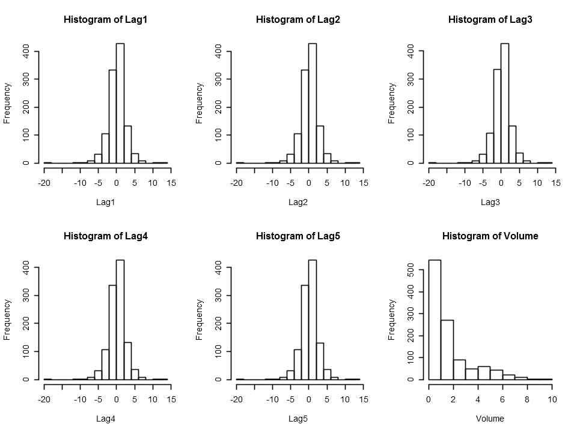

```r
par(mfrow=c(2,3))
hist(Lag1)
hist(Lag2)
hist(Lag3)
hist(Lag4)
hist(Lag5)
hist(Volume)
```

### (b) Use the full data set to perform a logistic regression with Direction as the response and the five lag variables plus Volume as predictors.

```r
glm.fit <- glm(Direction~Lag1+Lag2+Lag3+Lag4+Lag5+Volume, data=Weekly, family=binomial)
```

```r
summary(glm.fit)
```

```
Call:
glm(formula = Direction ~ Lag1 + Lag2 + Lag3 + Lag4 + Lag5 +
    Volume, family = binomial, data = Weekly)

Deviance Residuals:
    Min       1Q   Median       3Q      Max
-1.6949  -1.2565   0.9913   1.0849   1.4579

Coefficients:
            Estimate Std. Error z value Pr(>|z|)
(Intercept)  0.26686    0.08593   3.106   0.0019 **
Lag1        -0.04127    0.02641  -1.563   0.1181
Lag2         0.05844    0.02686   2.175   0.0296 *
Lag3        -0.01606    0.02666  -0.602   0.5469
Lag4        -0.02779    0.02646  -1.050   0.2937
Lag5        -0.01447    0.02638  -0.549   0.5833
Volume      -0.02274    0.03690  -0.616   0.5377
---
Signif. codes:  0 '***' 0.001 '**' 0.01 '*' 0.05 '.' 0.1 ' ' 1

(Dispersion parameter for binomial family taken to be 1)

    Null deviance: 1496.2  on 1088  degrees of freedom
Residual deviance: 1486.4  on 1082  degrees of freedom
AIC: 1500.4

Number of Fisher Scoring iterations: 4
```

Lag2 seems to be statistically significant with p < 0.05

### (c) Compute the confusion matrix and overall fraction of correct predictions.

```r
glm.prob <- predict(glm.fit, type="response")
```

```r
glm.pred <- rep("Down", nrow(Weekly))
```

```r
glm.pred[glm.prob > 0.5] = "Up"
```

```r
table(glm.pred, Direction)
```

```
        Direction
glm.pred Down  Up
    Down   54  48
    Up    430 557
```

```r
mean(glm.pred == Direction)
```

0.561065197428834

```r
(54+557)/1089
```

0.561065197428834

"100 - 56.1 = 43.9% is the training error rate. The training error rate is often overly optimistic - it tends to underestimate the test error rate. In order to better assess the accuracy of the logistic regression model in this setting, we can fit the model using part of the data, and then examine how well it predicts the held out data. This will yield a more realistic error rate, in the sense that in practice we will be interested in our model's performance not on the data that we used to fit the model, but rather on days in the future for which the market's movements are unknown."

책의 158페이지 두 번째 문단의 내용을 인용하였습니다.

### (d) Now fit the logistic regression model using a training data period from 1990 to 2008, with Lag2 as the only predictor.

```r
training <- Year < 2009
```

```r
Weekly.0910 <- Weekly[!training,]
```

```r
Direction.0910 <- Direction[!training]
```

```r
glm.fit2 <- glm(Direction~Lag2, data=Weekly, family=binomial, subset=training)
```

```r
glm.probs2 = predict(glm.fit2, Weekly.0910, type="response")
```

```r
glm.pred2 <- rep("Down", length(Direction.0910))
```

```r
glm.pred2[glm.probs2 > 0.5] = "Up"
```

```r
table(glm.pred2, Direction.0910)
```

```
         Direction.0910
glm.pred2 Down Up
     Down    9  5
     Up     34 56
```

```r
mean(glm.pred2 == Direction.0910)
```

0.625

### (e) Repeat (d) using LDA.

```r
library(MASS)
lda.fit = lda(Direction ~ Lag2, data = Weekly, subset = training)
lda.class = predict(lda.fit, Weekly.0910)$class
table(lda.class, Direction.0910)
```

```
         Direction.0910
lda.class Down Up
     Down    9  5
     Up     34 56
```

### (f) Repeat (d) using QDA.

```r
qda.fit = qda(Direction ~ Lag2, data = Weekly, subset = training)
qda.class = predict(qda.fit, Weekly.0910)$class
table(qda.class, Direction.0910)
```

```
         Direction.0910
qda.class Down Up
     Down    0  0
     Up     43 61
```

```r
mean(qda.class==Direction.0910)
```

0.586538461538462

### (g) Repeat (d) using KNN with $K$ = 1

```r
train.X = as.matrix(Lag2[training])
```

```r
test.X = as.matrix(Lag2[!training])
```

```r
train.Y = as.matrix(Direction[training])
```

```r
library(class)
set.seed(1)
knn.pred = knn(train.X, test.X, train.Y, k=1)
```

```r
table(knn.pred, Direction.0910)
```

```
        Direction.0910
knn.pred Down Up
    Down   21 30
    Up     22 31
```

```r
mean(knn.pred == Direction.0910)
```

0.5

# 11.

### (a) Create a binary variable, mpg01, that contains a 1 if mpg contains a value above its median, and a 0 if mpg contains a value below its median.

```r
Auto2 <- data.frame(Auto)
```

```r
Auto2$mpg01 <- rep(0, nrow(Auto2))
```

```r
Auto2$mpg01[Auto2$mpg > median(Auto2$mpg)] = 1
```

### (b) Explore the data graphically in order to investigate the association between mpg01 and the other features.

```r
library(corrplot)
```

```r
M <- cor(Auto2[,-9])
```

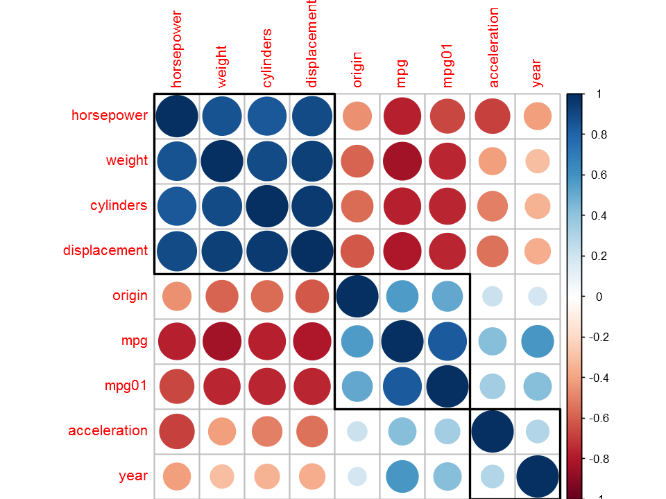

```r
# https://cran.r-project.org/web/packages/corrplot/vignettes/corrplot-intro.html

cor.mtest <- function(mat, conf.level = 0.95){
  mat <- as.matrix(mat)
    n <- ncol(mat)
    p.mat <- lowCI.mat <- uppCI.mat <- matrix(NA, n, n)
    diag(p.mat) <- 0
    diag(lowCI.mat) <- diag(uppCI.mat) <- 1
    for(i in 1:(n-1)){
        for(j in (i+1):n){
            tmp <- cor.test(mat[,i], mat[,j], conf.level = conf.level)
            p.mat[i,j] <- p.mat[j,i] <- tmp$p.value
            lowCI.mat[i,j] <- lowCI.mat[j,i] <- tmp$conf.int[1]
            uppCI.mat[i,j] <- uppCI.mat[j,i] <- tmp$conf.int[2]
        }
    }
    return(list(p.mat, lowCI.mat, uppCI.mat))
}

res1 <- cor.mtest(Auto2[,-9],0.95)
corrplot(M, p.mat = res1[[1]], order="hclust", insig = "pch", addrect=3)
```

```r
sort(cor(Auto2[,-9])[,"mpg01"], decreasing=T)
```

**mpg01**

1

**mpg**

0.836939229153618

**origin**

0.513698448318672

**year**

0.429904226574927

**acceleration**

0.346821530080934

**horsepower**

-0.667052581047159

**displacement**

-0.753476593523588

**weight**

-0.75775657142698

**cylinders**

-0.75919388654222

더 궁금하신 분들은 써 놓은 웹사이트에 가서 해당 library(corrplot)에 대한 설명을 참고하시기 바랍니다. 보기 쉬워서 좋네요.

위의 행렬을 통해 살펴보면, 검은 테두리로 구분된 부분이 특별히 높은 양의 상관관계를 가진 변수들끼리 묶어 놓은 것입니다. 묶이지 않았지만 빨간 색이 진할수록 음의 상관관계가 큰 것입니다.

### (c) Split the data into a training set and a test set.

```r
attach(Auto2)
```

```r
train <- year < 76
```

```r
Auto2.test <- Auto2[!train,]
```

### (d) Perform LDA on the training data in order to predict mpg01 using the variables that seemed most associated with mpg01 in (b). What is the test error of the model obtained?

```r
lda.fit <- lda(mpg01~horsepower+weight+cylinders+displacement, data=Auto2, subset=
train)
```

```r
lda.class <- predict(lda.fit, Auto2.test)$class
```

```r
table(lda.class, Auto2.test$mpg01)
```

```
lda.class   0   1
        0  66  15
        1   8 123
```

```r
mean(lda.class != Auto2.test$mpg01)
```

0.108490566037736

### (e) Perform QDA on the training data in order to predict mpg01 using the variables that seemed most associated with mpg01 in (b). What is the test error of the model obtained?

```r
qda.fit <- qda(mpg01~horsepower+weight+cylinders+displacement, data=Auto2, subset=
train)
```

```r
qda.class <- predict(qda.fit, Auto2.test)$class
```

```r
table(qda.class, Auto2$mpg01[!train])
```

```
qda.class   0   1
        0  70  21
        1   4 117
```

```r
mean(qda.class != Auto2$mpg01[!train])
```

0.117924528301887

### (f) Perform logistic regression on the training data...

```r
glm.fit <- glm(mpg01~horsepower+weight+cylinders+displacement, data=Auto2, family=binomial,subset=train)
```

```r
glm.probs <- predict(glm.fit, Auto2.test, type="response")
```

```r
glm.pred <- rep(0, length(glm.probs))
```

```r
glm.pred[glm.probs > 0.5] = 1
```

```r
table(glm.pred, Auto2.test$mpg01)
```

```
glm.pred  0  1
       0 73 39
       1  1 99
```

```r
mean(glm.pred != Auto2.test$mpg01)
```

0.188679245283019

### (g) Perform KNN on the training data, with several values of K, in order to predict mpg01.

```r
train.X = cbind(horsepower, weight, cylinders, displacement)[train,]
```

```r
test.X = cbind(horsepower, weight, cylinders, displacement)[!train,]
```

```r
train.Y = mpg01[train]
```

```r
set.seed(1)
knn.pred <- knn(train = train.X, test = test.X, train.Y, k=1)
```

```r
table(knn.pred, mpg01[!train])
```

```
knn.pred   0   1
       0  72  29
       1   2 109
```

```r
mean(knn.pred != mpg01[!train])
```

0.14622641509434

# 12.

### (a)

```r
Power <- function(){
    x = 2^3
    print(x)
    }
```

```r
Power()
```

```
[1] 8
```

### (b)

```r
Power2 <- function(x, a){
    print(x^a)
}
```

```r
Power2(2,3)
```

```
[1] 8
```

```r
Power2(3, 8)
```

```
[1] 6561
```

### (c)

```r
Power2(10, 3)
```

```
[1] 1000
```

```r
Power2(8, 17)
```

```
[1] 2.2518e+15
```

```r
Power2(131, 3)
```

```
[1] 2248091
```

### (d)

```r
Power3 <- function(x, a){
    result = x^a
    return(result)
}
```

```r
data1 <- data.frame(1:10, Power3(1:10, 2))
colnames(data1) <- c("x", "x^2")
```

```r
library(ggplot2)
```

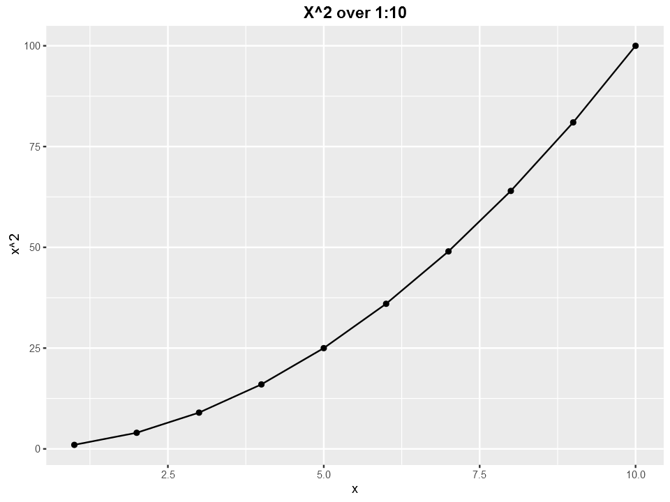

```r
ggplot(data1, aes(x=x, y=x^2))+geom_point()+geom_line()+ggtitle("X^2 over 1:10") +
     theme(plot.title = element_text(lineheight=.8, face="bold"))
```

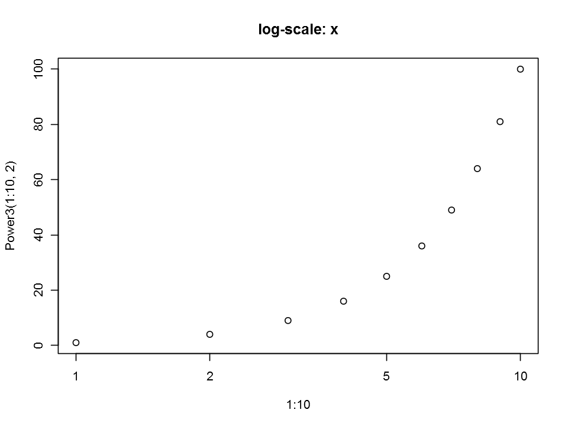

```r
plot(x=1:10, Power3(1:10,2), log = "x", main = "log-scale: x")
```

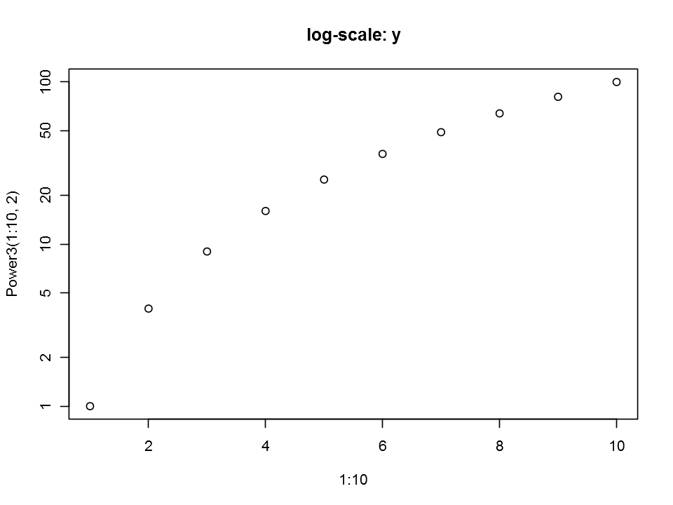

```r
plot(1:10, Power3(1:10,2), log="y", main = "log-scale: y")
```

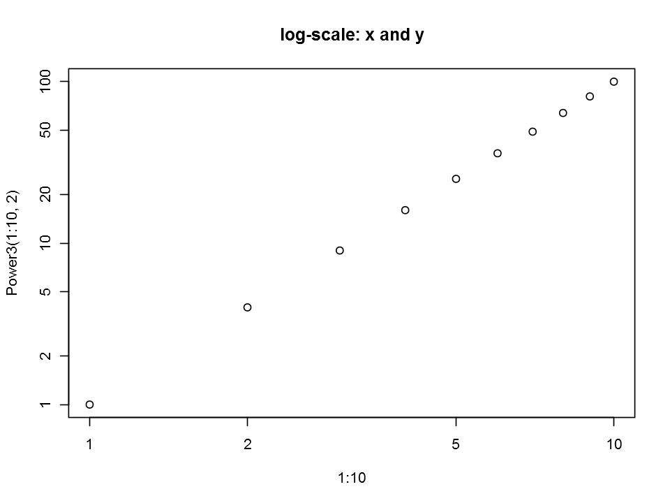

```r
plot(1:10, Power3(1:10,2), log="xy", main = "log-scale: x and y")
```

### (f)

```r
PlotPower <- function(x, a){
    plot(x, Power3(x,a))
}
```

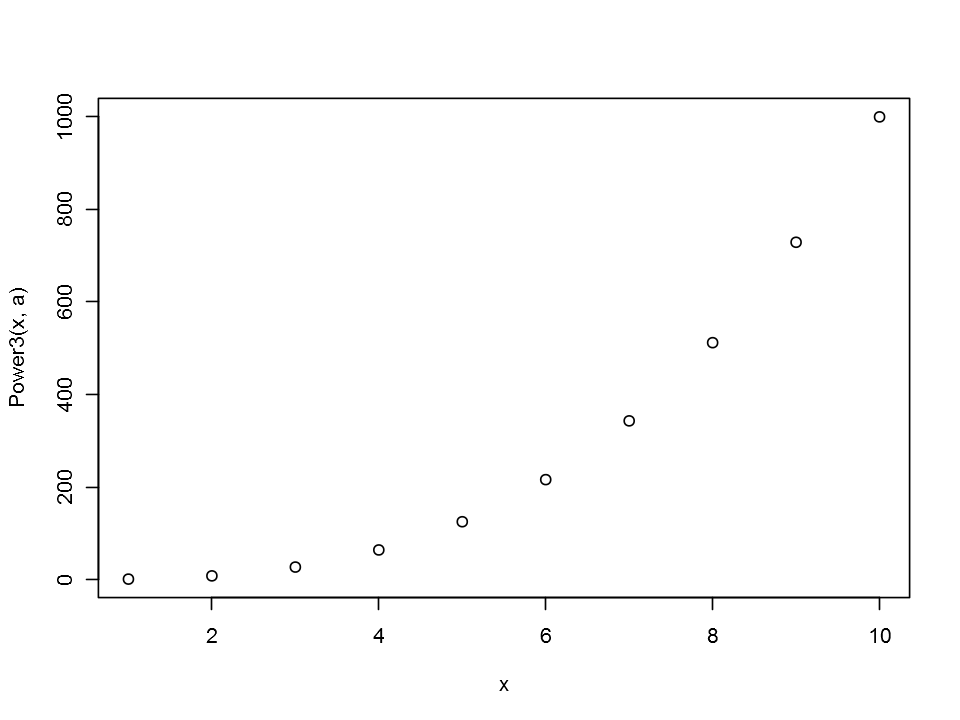

```r
PlotPower(1:10, 3)
```

# 13.

```r
Boston2 <- data.frame(Boston)
```

```r
Boston2$crim1 = rep(0, nrow(Boston2))
```

```r
Boston2$crim1[Boston2$crim > median(Boston2$crim)] = 1
```

```r
attach(Boston2)
```

### Logistic regression

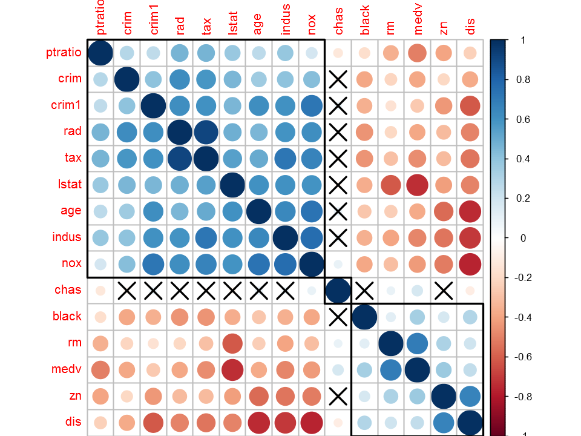

```r
M <- cor(Boston2)
res1 <- cor.mtest(Boston2,0.99)
corrplot(M, p.mat = res1[[1]], order="hclust", insig = "pch", addrect=3)
```

```r
sort(cor(Boston2)["crim1",], decreasing=T)
```

**crim1**

1

**nox**

0.723234795033279

**rad**

0.619786249019655

**age**

0.613939920691306

**tax**

0.608741282861181

**indus**

0.603260171570645

**lstat**

0.453262732445493

**crim**

0.409395452845748

**ptratio**

0.253568363203434

**chas**

0.0700967743894098

**rm**

-0.156371775122888

**medv**

-0.263016734209019

**black**

-0.351210933644617

**zn**

-0.436151025936314

**dis**

-0.616341641825828

crim1과 상관계수의 절대값이 0.5 이상인 변수들은 nox, rad, age, tax, indus, dis 로 보입니다. 그러므로 crim1을 해당 변수들로 예측했습니다. 다른 조합도 얼마든 가능합니다.

```r
# Select the random half
set.seed(1)
train <- sample(nrow(Boston2), 253)
```

```r
test <- (1:nrow(Boston2))[-train]
```

```r
glm.fit <- glm(crim1 ~ nox+rad+age+tax+indus+dis, data=Boston2, subset=train)
```

```r
glm.prob <- predict(glm.fit, Boston2[test,], type="response")
```

```r
glm.pred <- rep(0, 253)
```

```r
glm.pred[glm.prob > 0.5] = 1
```

```r
table(glm.pred, Boston2[test,]$crim1)
```

```
glm.pred   0   1
       0 120  37
       1   6  90
```

```r
# error rate of logistic regression model
mean(glm.pred!=Boston2[test,]$crim1)
```

0.1699604743083

### LDA

```r
lda.fit <- lda(crim1~nox+rad+age+tax+indus+dis, data=Boston2, family=binomial, subset=train)
```

```r
lda.class <- predict(lda.fit, Boston2[test, ])$class
```

```r
table(lda.class, Boston2[test,]$crim1)
```

```
lda.class   0   1
        0 120  37
        1   6  90
```

```r
# error rate of lda model
mean(lda.class != Boston2[test,]$crim1)
```

0.1699604743083

### KNN

```r
train.X = cbind(nox, rad, age, tax, indus, dis)[train,]
```

```r
test.X = cbind(nox, rad, age, tax, indus, dis)[test,]
```

```r
train.Y = crim1[train]
```

```r
# knn with k = 1
knn.pred <- knn(train.X, test.X, train.Y, k=1)
```

```r
table(knn.pred, Boston2[test,]$crim1)
```

```
knn.pred   0   1
       0 113  13
       1  13 114
```

```r
mean(knn.pred != Boston2[test,]$crim1)
```

0.102766798418972

```r
# knn with k = 10
knn.pred10 <- knn(train.X, test.X, train.Y, k=10)
```

```r
mean(knn.pred10 != Boston2[test,]$crim1)
```

0.16600790513834

```r
# knn with k = 100
knn.pred100 <- knn(train.X, test.X, train.Y, k=100)
```

```r
mean(knn.pred100 != Boston2[test,]$crim1)
```

0.276679841897233